```python
import pandas as pd
import matplotlib.pyplot as plt
import seaborn as sns
```

```python
sportasi = pd.read_excel ("sportasi_zscore.xlsx")
```

# Dataset sportaši

## Imamo informacije o njihovoj starosti te o njihovoj visini - recimo da se bavimo teretanama i jako nam je važno imati podatke o starosti i visini nađih sportaša

## Želimo vidjeti ima li unutar dataseta nekih ekstremnih vrijednosti koje tu ne pripadaju

## U realnom svijetu vrlo rijetko ćemo dobiti savršen dataset bez grešaka

```python
sportasi.head()
```

|  | Age | Height |
| --- | --- | --- |
| 0 | 41 | 185 |
| 1 | 29 | 180 |
| 2 | 34 | 175 |
| 3 | 48 | 160 |
| 4 | 32 | 192 |

```python
sportasi.describe()
```

|  | Age | Height |
| --- | --- | --- |
| count | 199.000000 | 199.000000 |
| mean | 41.206030 | 186.417085 |
| std | 15.411289 | 10.077072 |
| min | -27.000000 | 150.000000 |
| 25% | 32.000000 | 181.000000 |
| 50% | 41.000000 | 187.000000 |
| 75% | 51.000000 | 192.000000 |
| max | 147.000000 | 228.000000 |

## Primjećene su neke čudne ekstremne vrijednosti koje mogu utjecati na našu daljnju analizu.

## Mnogi ML algoritmi kao i neuronske mreže su vrlo osjetljive na ekstremne vrijednosti i mogu "povući" rezultate u totalno krivom smjeru

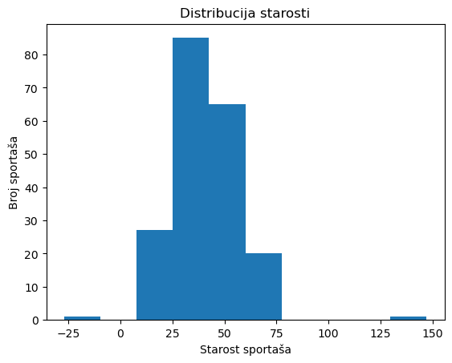

```python
plt.hist (sportasi.Age)
plt.xlabel ("Starost sportaša")
plt.ylabel ("Broj sportaša")
plt.title ("Distribucija starosti")
```

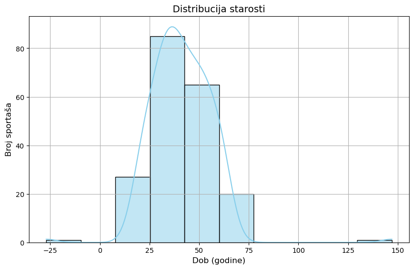

```python
plt.figure(figsize=(10, 6))
sns.histplot(sportasi["Age"], bins=10, kde=True, color='skyblue', edgecolor='black')
plt.title("Distribucija starosti", fontsize=14)
plt.xlabel("Dob (godine)", fontsize=12)
plt.ylabel("Broj sportaša", fontsize=12)
plt.grid(True)
plt.tight_layout()
```

## Onjašnjenje grafikona - i sns library ima histograme. Koristimo dodatni parametar kde kako bismo dobili i glatku kontinuiranu liniju koja prikazuje procijenjenju distribuciju podataka (zaglađena verzija histograma)

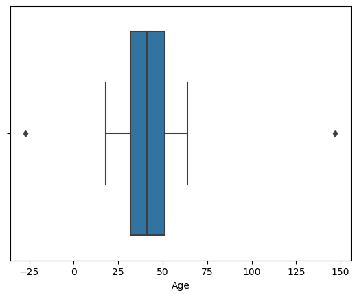

```python
sns.boxplot (x = sportasi["Age"])
```

# Uz statistički prikaz varijable Age, napravili smo i grafički prikaz koji nam potvrđuje prisustvo outliera

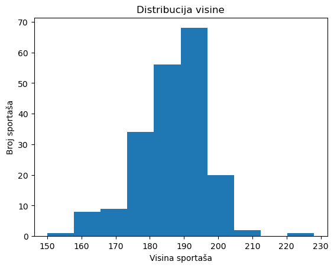

```python
plt.hist (sportasi.Height)
plt.xlabel ("Visina sportaša")
plt.ylabel ("Broj sportaša")
plt.title ("Distribucija visine")
```

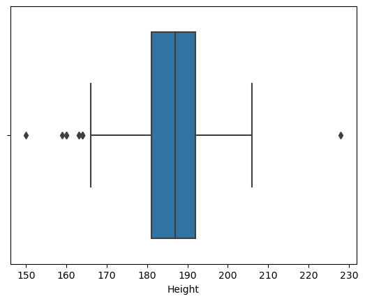

```python
sns.boxplot (x = sportasi["Height"])
```

## Također i na grafičkom prikazu za varijablu Height vidimo prisustvo outliera

## Prvo ćemo identificirati outliere u varijabli Age

## Za to postoji nekoliko načina

## Kako bi nam originalni dataset ostao sačuvan, napravit ćemo kopije originala na kojem istražujemo metode

## Originalni dataset se neće mijenjati, poželjno je ostaviti original netaknut kako bismo se mogli vratiti ako nam se nešto ne svidja

```python
sportasi2 = sportasi.copy()
```

```python
sportasi2.head()
```

|  | Age | Height |
| --- | --- | --- |
| 0 | 41 | 185 |
| 1 | 29 | 180 |
| 2 | 34 | 175 |
| 3 | 48 | 160 |
| 4 | 32 | 192 |

## Prvo ćemo koristiti metodu sortiranja

```python
sportasi2.sort_values (by = ["Age"])
```

|  | Age | Height |
| --- | --- | --- |
| 75 | -27 | 181 |
| 197 | 18 | 184 |
| 114 | 18 | 184 |
| 33 | 19 | 185 |
| 175 | 19 | 189 |
| ... | ... | ... |
| 41 | 64 | 186 |
| 119 | 64 | 187 |
| 176 | 64 | 191 |
| 151 | 64 | 191 |
| 135 | 147 | 182 |

199 rows × 2 columns

## Ako poznajemo domenu koju istražujemo, naša ekspertiza može biti dovoljna da odredimo što je zaista outlier

## Osobe koje su stare -27 godina te 147 godina su očito outlieri

## Na ovom primjeru ćemo te redove obrisati korištenjem naredbe drop

## Brisanje kao metoda nije najpopularnija, jer gubite podatke

## Brisanje je prihvatljivo ako brišete samo manji dio podataka, do 3 %. Ako imate male datasetove, čak i 3 % je previše

```python
sportasi2 = sportasi2.drop (labels = [75, 135], axis = 0)
```

## Labels označava indeksni broj, axis = 0 označava da se radi o brisanju redova

```python
sportasi2.describe()
```

|  | Age | Height |
| --- | --- | --- |
| count | 197.000000 | 197.000000 |
| mean | 41.015228 | 186.467005 |
| std | 12.611736 | 10.115919 |
| min | 18.000000 | 150.000000 |
| 25% | 32.000000 | 181.000000 |
| 50% | 41.000000 | 187.000000 |
| 75% | 51.000000 | 192.000000 |
| max | 64.000000 | 228.000000 |

```python
sportasi2.head()
```

|  | Age | Height |
| --- | --- | --- |
| 0 | 41 | 185 |
| 1 | 29 | 180 |
| 2 | 34 | 175 |
| 3 | 48 | 160 |
| 4 | 32 | 192 |

```python
sportasi2.sort_values (by = ["Age"])
```

|  | Age | Height |
| --- | --- | --- |
| 197 | 18 | 184 |
| 114 | 18 | 184 |
| 175 | 19 | 189 |
| 33 | 19 | 185 |
| 31 | 19 | 187 |
| ... | ... | ... |
| 141 | 63 | 185 |
| 176 | 64 | 191 |
| 41 | 64 | 186 |
| 151 | 64 | 191 |
| 119 | 64 | 187 |

197 rows × 2 columns

## Odluka što će se raditi s outlierima je na osobi koja čisti podatke.

## Osim brisanja, može se vrijednost outliera zamijeniti i jednom drugom koja generalno predstavlja podatke - metoda imputacije

## Outliere ćemo zamijeniti s prosjekom kako ne bismo gubili podatke, koji put ih nemamo dovoljno da si dopustimo brisanje

```python
sportasi3 = sportasi.copy()
```

## Napravili smo novu kopiju originalnog dataseta i sad opet imamo outliere. Ne želimo ih brisati nego zanijeniti s prosjekom stupca (Age)

## Koliko iznosi prosjek godina?

```python
sportasi3.head()
```

|  | Age | Height |
| --- | --- | --- |
| 0 | 41 | 185 |
| 1 | 29 | 180 |
| 2 | 34 | 175 |
| 3 | 48 | 160 |
| 4 | 32 | 192 |

```python
sportasi3.describe()
```

|  | Age | Height |
| --- | --- | --- |
| count | 199.000000 | 199.000000 |
| mean | 41.206030 | 186.417085 |
| std | 15.411289 | 10.077072 |
| min | -27.000000 | 150.000000 |
| 25% | 32.000000 | 181.000000 |
| 50% | 41.000000 | 187.000000 |
| 75% | 51.000000 | 192.000000 |
| max | 147.000000 | 228.000000 |

```python
sportasi3.sort_values (by = ["Age"])
```

|  | Age | Height |
| --- | --- | --- |
| 75 | -27 | 181 |
| 197 | 18 | 184 |
| 114 | 18 | 184 |
| 33 | 19 | 185 |
| 175 | 19 | 189 |
| ... | ... | ... |
| 41 | 64 | 186 |
| 119 | 64 | 187 |
| 176 | 64 | 191 |
| 151 | 64 | 191 |
| 135 | 147 | 182 |

199 rows × 2 columns

```python
outlier_index = [75,135]
```

## Na osnovi sortiranih podataka napravili smo varijablu u koju pohranjujemo indexe svih naših outliera. U slučaju da ih je puno više i ne vidimo ih sad, možemo modificirati naredbe head () i tail ()

## Indexi označavaju redni broj retka u datasetu, ne vrijednost tog retka

```python
type (outlier_index)
```

```
list
```

```python
mean_non_outliers = sportasi3.drop(outlier_index)["Age"].mean()
```

## Računamo prosjek za našu varijablu Age. Iz izračuna mičemo naše outliere jer ne želimo da utječe na naš izračun

```python
mean_non_outliers
```

```
41.015228426395936
```

```python
sportasi3.loc[outlier_index, "Age"] = int(mean_non_outliers)
```

```python
sportasi3.loc[outlier_index, "Age"] = mean_non_outliers
```

## U datasetu sportasi3 zamjenjujemo vrijednosti u redovima s indexom 75 i 135 s vrijednošču prosjeka

```python
sportasi3.describe()
```

[output not shown]

```python
sportasi3.loc [75]
```

[output not shown]

```python
sportasi3.loc [[75, 135]]
```

|  | Age | Height |
| --- | --- | --- |
| 75 | 41.015228 | 181 |
| 135 | 41.015228 | 182 |

# **Zadatak 1**

## Učitati dataset stanovi_zagreb.xlsx

## Pronaći varijable koje imaju outliere (ima ih više)

## Na jednoj varijabli pokazati kako se rješavaju outlieri brisanjem

## Na drugoj varijabli pokazati kako se rješavaju outlieri imputacijom aritmetičke sredine